# Central Tendency

Data Analysis for Psychology in R 1

Tom Booth

Click for slides

## Today

- Introduce frequency distribution
- Discuss measures of central tendency
  - Mode
  - Median
  - Mean

## Learning objectives

- Understand visualizations of frequency distributions.
- Be able to define the mode, median and mean.
- Understand how to calculate these values by hand and in R.
- Understand which statistic to use for different types of data.

## Frequency Distribution

*“a mathematical function showing the number of instances in which a variable takes each of its possible values.”*

## Graphs

- There are many types of graph, all of which are intended to summarise different types of data, or the relations between data.
- We are going to spend a lot of time dealing with plots this semester.
- Let’s pause for a moment and consider the basic structure

## Structure of graphics

- Data
- Axes
  - (aesthetics in `ggplot` language - also includes size, colours etc.)
- Axes have scales
- Geometric objects
  - (`geoms` in `ggplot` language; i.e. bars, points, lines)

## Bar plot

- Bar plots are used to show frequency distributions of categorical variables.
- Our example:
  - Data = result of our 10 coin tosses.
  - X-axis: values of variable (here “Heads” or "Tails)
    - Scale = two discrete values
  - Y-axis: Frequency
    - Scale = count

## Histogram

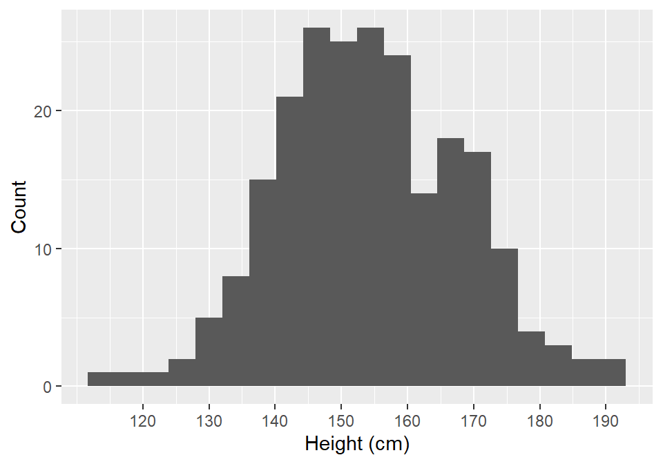

- A histogram is used to show the frequency distribution for continuous variables
- Our example:
  - Data = heights of the class
  - X-axis: possible values of height.
    - Commonly presented in “bins”
    - A bin represents a range of scores (plot can look very different dependent on this)
    - Scale = dependent on the form of measurement, here centimetres
  - Y-axis: frequency of a given value or values within “bins”

## Describing in numbers

- So how do we describe a frequency distribution numerically?
- We typically want to know something about the;
  - central point, and
  - the spread (or dispersion around centre point)

## Central tendency

- Central tendency measures are a set of statistics that describe the central point of data.
  - Or the central point of our frequency distributions.
- Measures of central tendency are typically referred to as “averages”
  - But this can have many meanings.

## Some data…

```r
ex1 <- tibble(
    ID = c(paste("ID", 101:250, sep = "")),
    Degree = factor(sample(c("Psych", "Ling", "Phil", "Joint"),
                           150, replace=T, prob=c(.3,.3,.3,.1))),
    StatsScore = round(rnorm(150, 66, 7),0)
)
```

```r
ex1[1:10,]
# A tibble: 10 x 3
   ID    Degree StatsScore
   <chr> <fct>       <dbl>
 1 ID101 Phil           66
 2 ID102 Joint          62
 3 ID103 Joint          66
 4 ID104 Psych          70
 5 ID105 Psych          67
 6 ID106 Phil           51
 7 ID107 Ling           52
 8 ID108 Psych          77
 9 ID109 Psych          66
10 ID110 Ling           70
```

| ID | Degree | StatsScore |
| --- | --- | --- |
| ID101 | Phil | 66 |
| ID102 | Joint | 62 |
| ID103 | Joint | 66 |
| ID104 | Psych | 70 |
| ID105 | Psych | 67 |
| ID106 | Phil | 51 |
| ID107 | Ling | 52 |
| ID108 | Psych | 77 |
| ID109 | Psych | 66 |
| ID110 | Ling | 70 |

## Central Tendency: Mode

- One way to consider the average value is the **mode.**
- **Mode**: The most commonly observed value in the data set.
- It is of course possible that we observe two (or more) values with equal frequency.
- We then have a **multi-modal** distribution.

```r
table(ex1$Degree)

Joint  Ling  Phil Psych
   10    49    40    51
```

## Central Tendency: Median

- A second measure of average observation is the **median.**
- **Median:** is the value for which half the data falls above, and half below the given value.
- To calculate the median:
  - Rank order the data.
  - Find the middle value.

## Hand calculation

- When we have an odd number of observations:

$$\frac{1}{2}(N+1)$$

- [10,40,30,25,15,5,65]
- When we have an even number of observations:

$$\frac{\frac{1}{2}N + (\frac{1}{2}N+1)}{2}$$

- [10,40,25,15,5,30]

## Median in R

```r
ex1 %>%
    summarise(
        median = median(StatsScore)
    )
# A tibble: 1 x 1
  median
   <dbl>
1     66
```

## Central Tendency: Mean

- A third measure of average observation is the **arithmetic mean.**
- **Mean:** is the sum of all values, divided by the total number of observations.
  - I.e. this is the average as most people think about the average.

$$\bar{x} = \frac{\sum_{i=1}^{N}{x_i}}{N}$$

$$\bar{x} = \frac{\sum_{i=1}^{N}{x_i}}{N}$$

- $\bar{x}$ = estimate of mean of variable x
- $x_i$ = individual values of x
- $N$ = sample size

$$\bar{x} = \frac{\sum_{i=1}^{N}{x_i}}{N}$$

- [10,40,30,25,15,5]

## Central Tendency: Arithmetic Mean

```r
ex1 %>%
    summarise(
        median = median(StatsScore),
        mean = mean(StatsScore)
    )
# A tibble: 1 x 2
  median  mean
   <dbl> <dbl>
1     66  66.1
```

## Strengths and weaknesses

| Measure | Strength | Weakness |
| --- | --- | --- |
| Mode | Actually occurs in our data | Not algebraically calculable |
|  | Unaffected by extreme values | Probably does not exist for true continuous data (think reaction time) |
| Median | No assumptions about interval value of data | Not relatable to measures of dispersion (see next week) |
|  | Unaffected by extreme values |  |
| Mean | Algebraically tractable | Sensitive to extreme values |
|  | Related to measures of dispersion (see next week) | Assumes data are interval or better |
|  |  | Possible no case in your data takes the value of the mean |

## Which measure should we use?

| Variable Type | Central Tendency |
| --- | --- |
| Categorical (Nominal) | Mode |
| Categorical (Ordered) | Mode/Median |
| Continuous | Mean (any in fact) |
| Count | Mode (mean) |

- Depends on the level of measurement.

## Tasks for this week…

1. Finish any existing tasks from lab 3.
2. Reading: See LEARN
3. Quiz 4
   - **This quiz counts**
   - Live now (as of Monday at 09:00).
   - Closes Sunday at 17:00

## Recommendations of the week

- Podcast: [History of Rome](https://thehistoryofrome.typepad.com/) (find it on usual podcast site)
- Recipe: [Cullen Skink](https://www.bbcgoodfood.com/recipes/899633/cullen-skink)
- Book: *Lucky Jim* by Kingsley Amis (In Main Library)
- Coffee/food Place: [Bearded Barista](https://twitter.com/beardedbarista_?lang=en)